# Final Project

Katie Webb

GEOG215, Introduction to Spatial Data Science

December 12, 2023

## Limited Healthy Food Access in North Carolina

### Introduction

This project examines the percentage of people across North Carolina who have limited access to sourcing healthy food. As described on the CHR website, this metric focuses on those who do not live close to a grocery store and are unable to access/buy fresh or local food (https://www.countyhealthrankings.org/explore-health-rankings/county-health-rankings-model/health-factors/health-behaviors/diet-and-exercise/limited-access-to-healthy-foods?year=2023). With the growing issue of food insecurity within North Carolina, this project will aim to visualize which counties experience this problem, and may indicate more about the general health of each county’s population. Having access to fresh food is a critical factor in promoting personal health and well-being. Those who do not have access to sourcing healthy food may be challenged with nutritional deficiencies and may not be informed about living a healthy lifestyle. This information is crucial to understanding which counties deserve priority for public-health resources and initiatives (i.e.: building more grocery stores for affected communities).

### Data Preparation

```r
# Load libraries
library(tidyverse)
library(sf)
library(tmap)
library(spdep)
library(knitr)
library(kableExtra)
```

```r
# Read original data layer
CHR <- read_csv("../raw_data/analytic_data2023_0.csv", skip = 1)

# Read in spatial layer
cnty_cb_sf <- read_sf("../raw_data/State_Owned_Lands_NC_Latest.gpkg")

# Select only the columns relating to the analysis of limited access to healthy foods
CHR <- CHR |>
    select("countycode",
            "state",
            "county",
            "v083_rawvalue")

# Rename columns
CHR <- CHR |>
 rename(COUNTYFP = `countycode`,
       STATE_ABV = `state`,
       COUNTY_NAME = county,
       LIMITED_HF_RAW = `v083_rawvalue`)

# Filter to only data in North Carolina
CHR <- CHR |>
  filter(STATE_ABV == "NC")

# Remove the first column of NC data
CHR <- CHR |>
        slice(-1)

# Filter spatial layer for only FIPS column
cnty_cb_sf <- cnty_cb_sf |>
  select("COUNTYFP")

# Table join
CHR_joined <- left_join(cnty_cb_sf,
                             CHR,
                             by = c("COUNTYFP"))

# Calculate percentage of limited access to healthy foods using the raw value
CHR_joined <- CHR_joined |>
  mutate(LIMITED_HF_RAW = as.numeric(LIMITED_HF_RAW),
         LIMITED_HF_PCT = LIMITED_HF_RAW * 100)
```

### Exploratory Spatial Data Analysis

#### Data Description and Summary

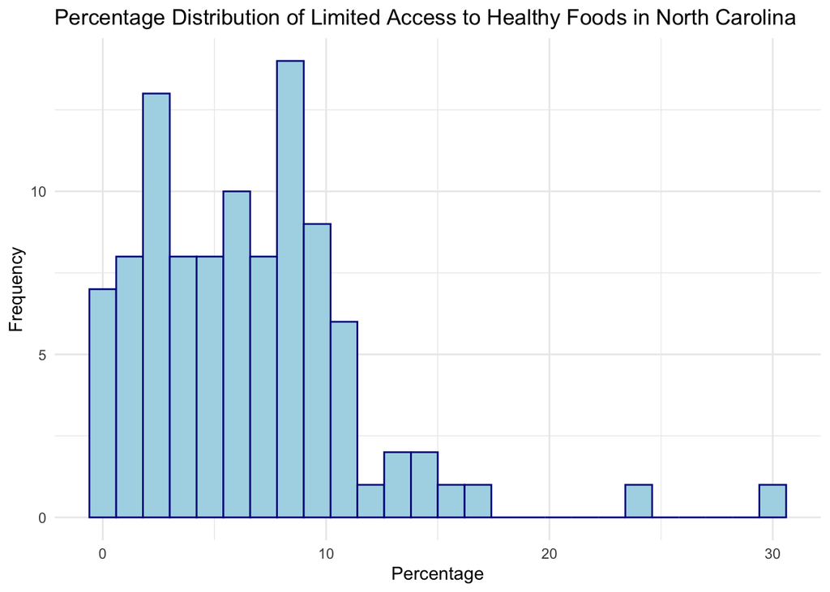

```r
# Get counts for number of observations
num_observations <- length(CHR_joined$LIMITED_HF_PCT)

# Get counts for number of NA values
num_na <- sum(is.na(CHR_joined$LIMITED_HF_PCT))

# Get measures of central tendencies
mean <- mean(CHR_joined$LIMITED_HF_PCT, na.rm = TRUE)
maximum <- max(CHR_joined$LIMITED_HF_PCT, na.rm = TRUE)
minimum <- min(CHR_joined$LIMITED_HF_PCT, na.rm = TRUE)

# Format measures of central tendencies as percentages
mean <- sprintf("%.2f%%", mean)
maximum <- sprintf("%.2f%%", maximum)
minimum <- sprintf("%.2f%%", minimum)

# Get measure for variation
variation <- sd(CHR_joined$LIMITED_HF_PCT, na.rm = TRUE)

## Create a percentage distribution histogram of LIMITED_HF_PERCENTAGE for NC
ggplot(CHR_joined, aes(x = LIMITED_HF_PCT)) +
  geom_histogram(binwidth = 1.2, fill = "lightblue", color = "darkblue") +
  labs(
    title = "Percentage Distribution of Limited Access to Healthy Foods in North Carolina",
    x = "Percentage",
    y = "Frequency"
  ) +
  theme_minimal()
```

```r
# Create a kable table
stats_table <- data.frame(
  "Metric" = c("Number of Observations", "Number of NA Values", "Mean", "Minimum", "Maximum", "Standard Deviation"),
  "Value" = c(num_observations, num_na, mean, minimum, maximum, variation)
)

# Print the table with styling and scrolling options
kable(stats_table, caption = "Descriptive Statistics", format = "html") %>%
  kable_styling(bootstrap_options = c("striped", "hover", "condensed", "responsive"), full_width = T) %>%
  scroll_box(width = "60%", height = "200px", fixed_thead = TRUE)
```

Descriptive Statistics

| Metric | Value |
| --- | --- |
| Number of Observations | 100 |
| Number of NA Values | 0 |
| Mean | 6.52% |
| Minimum | 0.07% |
| Maximum | 30.09% |
| Standard Deviation | 4.88446391377084 |

My variable of interest is the percentage of people who have limited access to healthy food in North Carolina. The average percentage of people in NC who have limited access to healthy food is 6.52%, with a maximum value of 30.09% and a minimum value of 0.07%. The data is variable, with a standard-deviation of 4.8844639. There are 100 observations, and 0 NA values. The histogram has a right-skewed distribution – most values fall near the lower percentages, with less values near the higher percentages.

#### Geographic Distribution and Clustering

```r
# Put map in view mode
tmap_mode("view")

## Subset data to only observations with values
CHR_joined <- CHR_joined |>
  filter(!is.na(LIMITED_HF_PCT))

## Create Queen case neighbors
CHR_joined_queen <- poly2nb(CHR_joined,
                       queen = TRUE)

## Convert neighbor object to weight matrix
CHR_joined_wm <-  nb2listw(CHR_joined_queen,
                         style = "B",         # B is binary (1,0)
                         zero.policy = TRUE)  # Allow obs with 0 neighbors

#
# Moran's I
#
CHR_joined_moran <- moran.test(CHR_joined$LIMITED_HF_PCT,     # Variable we're analyzing
                           listw = CHR_joined_wm,       # Sp weights matrix
                           alternative = "two.sided",  # Clustering or Dispersion
                           randomisation = TRUE,       # Compare to randomized values
                           zero.policy = TRUE)         # Allow obs with 0 neighbors

#### MORAN'S I VALUE ####
moran_i_value <- CHR_joined_moran$estimate[1]

#### P-Value for MORAN'S I ####
moran_p_value <- CHR_joined_moran$p.value

# Print summary
CHR_joined_moran
```

```
##
##  Moran I test under randomisation
##
## data:  CHR_joined$LIMITED_HF_PCT
## weights: CHR_joined_wm
##
## Moran I statistic standard deviate = -0.095012, p-value = 0.9243
## alternative hypothesis: two.sided
## sample estimates:
## Moran I statistic       Expectation          Variance
##      -0.015818093      -0.010101010       0.003620661
```

```r
#
# LISA -- Local Moran's I
#
CHR_joined_lisa <- localmoran(CHR_joined$LIMITED_HF_PCT,    # Variable we're analyzing
                          listw = CHR_joined_wm,      # Weights object
                          alternative = "two.sided", # Clustering or Dispersion
                          zero.policy = TRUE) %>%    # Best to keep TRUE for LISA
  as_tibble() |>                                     # Better object type
  mutate(across(everything(), as.vector))            # Remove junk from localmoran output


# Add values required for LISA category
CHR_joined_lisa <- CHR_joined_lisa |>
  mutate(SCVAR =  scale(CHR_joined$LIMITED_HF_PCT) |> as.vector(),            # Original data column
         LAGVAR = lag.listw(CHR_joined_wm, scale(CHR_joined$LIMITED_HF_PCT)),  # Lag of original data column
         LISACAT = case_when(SCVAR >= 0 & LAGVAR >= 0 & `Pr(z != E(Ii))` <= 0.05 ~ 1,
                             SCVAR <= 0 & LAGVAR <= 0 & `Pr(z != E(Ii))` <= 0.05 ~ 2,
                             SCVAR >= 0 & LAGVAR <= 0 & `Pr(z != E(Ii))` <= 0.05 ~ 3,
                             SCVAR <= 0 & LAGVAR >= 0 & `Pr(z != E(Ii))` <= 0.05 ~ 4,
                             `Pr(z != E(Ii))` > 0.05 ~ 5))

# Add label based on the LISACAT values
CHR_joined_lisa <- CHR_joined_lisa |>
  mutate(CATNAME = case_when(LISACAT == 1 ~ "HH",
                             LISACAT == 2 ~ "LL",
                             LISACAT == 3 ~ "HL",
                             LISACAT == 4 ~ "LH",
                             LISACAT == 5 ~ "Not Significant"))


## Add LISA category column to the spatial data
CHR_joined <- CHR_joined |>
  mutate(LISACAT = CHR_joined_lisa$LISACAT,
         CATNAME = CHR_joined_lisa$CATNAME)

# Print summary
CHR_joined_moran
```

```
##
##  Moran I test under randomisation
##
## data:  CHR_joined$LIMITED_HF_PCT
## weights: CHR_joined_wm
##
## Moran I statistic standard deviate = -0.095012, p-value = 0.9243
## alternative hypothesis: two.sided
## sample estimates:
## Moran I statistic       Expectation          Variance
##      -0.015818093      -0.010101010       0.003620661
```

```r
# Link to basemap background
bg_basemap <- "https://{s}.basemaps.cartocdn.com/rastertiles/voyager/{z}/{x}/{y}{r}.png"

# Create customized choropleth map
CHR_joined_choropleth <-
tm_shape(CHR_joined) +                      ## The R object
  tm_basemap(bg_basemap) +                  ## The basemap layer
  tm_polygons("LIMITED_HF_PCT",                       ## Column with the data
              title = "Limited Access to Healthy Foods (%)",   ## Legend title
              style = "jenks",               ## IMPORTANT: Classification Scheme!!
              palette = "Reds",              ## Color ramp for the polygon fills
              alpha = 0.9,                   ## Transparency for the polygon fills
              border.col = "black",          ## Color for the polygon lines
              border.alpha = 0.3,            ## Transparency for the polygon lines
              id = "COUNTY_NAME",                   ## Column used for the hover text
              popup.vars = c("LIMITED_HF_PCT")) +    ## Columns for click/popup text
  tm_layout(title = "North Carolina",
              legend.outside = TRUE,
              frame = FALSE)

# Create LISA map
CHR_joined_lisa_tmap <- tm_shape(CHR_joined,
                      projection = "ESRI:102003") +
  tm_polygons("LISACAT",
              title = "LISA Category",
              breaks = c(1, 2, 3, 4, 5, 6),
              palette =  c("red",
                           "blue",
                           "lightpink",
                           "skyblue",
                           "grey90"),
              colorNA = "white",
              labels = c("High-High",
                         "Low-Low",
                         "High-Low",
                         "Low-High",
                         "Not significant"),
              id = "COUNTY_NAME",
              border.col = "black",
              border.alpha = 0.25) +
  tm_layout(title = "North Carolina",
            frame = FALSE,
            legend.outside = TRUE)

# Map choropleth and LISA together
tmap_arrange(CHR_joined_choropleth,
             CHR_joined_lisa_tmap,
             ncol = 1,
             nrow = 2,
             sync = TRUE)
```

[interactive chart not shown]

The Choropleth Map demonstrates that most of the high percentages are found in Eastern North Carolina, with lower percentages in Western North Carolina. Central North Carolina has a more varied distribution, with some higher and moderate percentages, in addition to a few lower percentages. The Moran’s Test on this data provided a non-significant result with a p-value of 0.9243049, which suggests that we cannot reject the null hypothesis of spatial randomness. Moran’s Test Statistic of -0.0158181 indicates a small negative spatial correlation, but the non-significant p-value implies that this correlation is not statistically meaningful. For the LISA Test, there are 2 High-High clusters, 2 Low-High clusters, 2 Low-Low clusters, and 94 Not-Significant clusters. The High-High and Low-High clusters are both found in Eastern North Carolina, and the Low-Low clusters are seen in Western North Carolina. This emphasizes what was found in the Choropleth Map – higher percentages are found in Eastern NC, and lower percentages are seen in Western NC.

### Conclusions

This project demonstrates that although food insecurity is a prevalent issue within North Carolina, it is not spatially correlated with specific areas or counties given Moran’s Test. However, this could be the silver-lining within an otherwise disparaging topic, and may indicate that the issue is not strongly related to the land and natural resources themselves. While the concentration of High-High clusters in Eastern North Carolina is concerning, the lack of significant clusters in Central NC may suggest that there is more work and analysis to be done. I would be interested in seeing how the percentage of limited access to healthy food correlates with farmland availability. This could allow us to better understand the impact that natural resources and geographical features can have on accessing healthy food.

### Document Statistics

| Method | koRpus | stringi |
| --- | --- | --- |
| Word count | 677 | 690 |
| Character count | 4346 | 4346 |
| Sentence count | 34 | Not available |
| Reading time | 3.4 minutes | 3.5 minutes |